# Visualization Workflows

Adam Mattsson

2025-10-16

# 1 Introduction

This vignette provides a comprehensive guide to LundTaxR’s visualization functions (excluding the main heatmaps). Each section describes the function’s purpose, required and optional parameters, expected inputs, and output behavior, followed by practical examples with different parameter combinations. These tools help you interpret, present, and explore your classification results in a publication-ready format.

# 2 Forest Plots

## 2.1 `plot_ratio_forest`

**Purpose:** Visualizes odds ratios (from GLM) or hazard ratios (from Cox models) for a set of signature scores or predictors, using a forest plot. This function can call `get_glm` or `get_survival` internally, or accept precomputed data.

**Key Parameters:** - `these_predictions`, `these_samples_metadata`: Output from `classify_samples` and associated metadata (required unless `this_data` is provided) - `stat_plot`: Set to `"odds_ratio"` (GLM) or `"hazard_ratio"` (Cox) - `categorical_factor`: Categorical variable to test (for odds ratio) - `surv_time`, `surv_event`: Survival columns (for hazard ratio) - `predictor_columns`: Numeric columns to test (optional) - `this_subtype`, `subtype_class`: Focus on specific subtype(s) and class - `scale`, `bin_scores`, `n_bins`: Control scaling and binning of numeric scores - `col_bon`, `significant_p`, `sig_color`: Adjust p-values and highlight significance - `return_data`: Set to TRUE to return the data used for plotting

**Expected Inputs:** - Output from `classify_samples` and matching metadata, or a data frame from `get_glm`/`get_survival`

**Output:** - A forest plot (ggplot object) visualizing odds or hazard ratios, optionally with significance annotation

**Example: Odds Ratio for Gender**

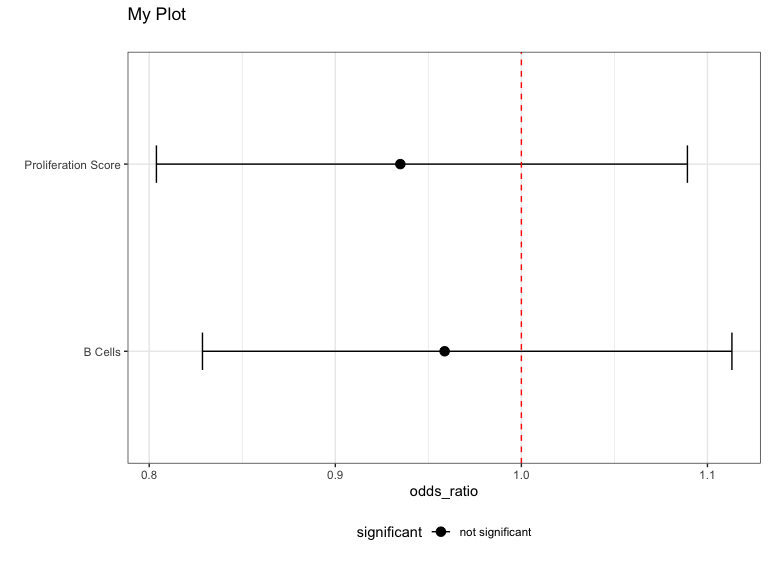

```r
# First, let's get the classification results
results <- classify_samples(
  this_data = sjodahl_2017,
  include_data = TRUE,
  verbose = FALSE
)

# Plot
plot_ratio_forest(
  these_predictions = results,
  these_samples_metadata = sjodahl_2017_meta,
  stat_plot = "odds_ratio",
  categorical_factor = "gender",
  predictor_columns = c("b_cells", "proliferation_score"),
  col_bon = TRUE,
  scale = 100
)
```

**Example: Hazard Ratio for Overall Survival**

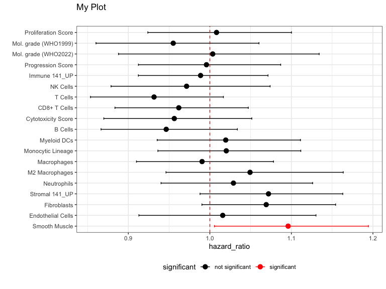

```r
plot_ratio_forest(
  these_predictions = results,
  these_samples_metadata = sjodahl_2017_meta,
  stat_plot = "hazard_ratio",
  surv_time = "surv_os_time",
  surv_event = "surv_os_event",
  n_bins = 10
)
```

## 2.2 `plot_subtype_forest`

**Purpose:** Creates a forest plot for multiple subtypes based on Cox proportional hazards models, including a table of sample and event counts per subtype.

**Key Parameters:** - `these_predictions`, `these_samples_metadata`: Output from `classify_samples` and metadata - `this_subtype`: Vector of subtypes to include (e.g., c(“Uro”, “GU”)) - `subtype_class`: “5_class” or “7_class” - `surv_event`, `surv_time`: Survival columns - `plot_title`, `plot_subtitle`, `plot_caption`: Plot annotations - `plot_width`, `plot_height`, `out_format`, `out_path`, `file_name`: Output controls - `significant_p`, `sig_color`: Significance annotation - `return_data`: Set to TRUE to return the plot data

**Expected Inputs:** - Output from `classify_samples` and matching metadata

**Output:** - A combined forest plot and summary table (ggplot/patchwork object)

**Example: All 5-class Subtypes, CSS Endpoint**

[figure not shown]

```r
plot_subtype_forest(
  these_samples_metadata = sjodahl_2017_meta,
  these_predictions = results,
  this_subtype = c("Uro", "GU", "BaSq", "Mes", "ScNE"),
  subtype_class = "5_class",
  surv_event = "surv_css_event",
  surv_time = "surv_css_time",
  plot_title = "CSS Hazard Ratios by Subtype"
)
```

**Example: UroA Only, PFS Endpoint**

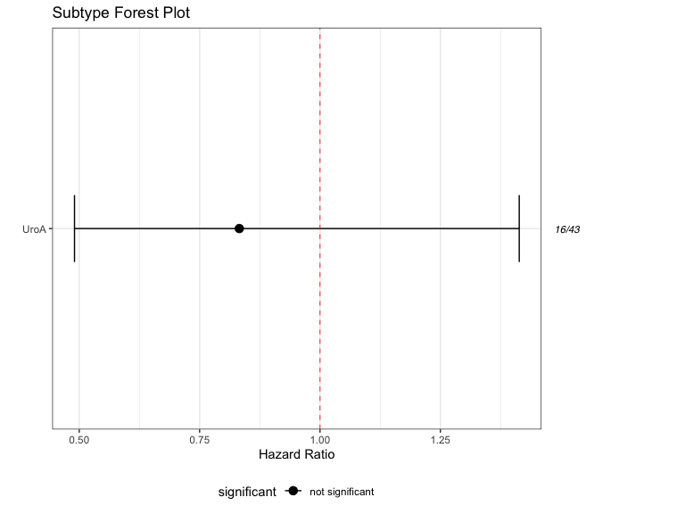

```r
plot_subtype_forest(
  these_samples_metadata = sjodahl_2017_meta,
  these_predictions = results,
  this_subtype = "UroA",
  subtype_class = "7_class",
  surv_event = "surv_pfs_event",
  surv_time = "surv_pfs_time"
)
```

# 3 Ranked Score Plots

## 3.1 `plot-ranked-score`

**Purpose:** Creates a point or segment plot of ranked signature scores for a selected variable, colored by subtype. Useful for visualizing score distributions and subtype separation.

**Key Parameters:** - `these_predictions`: Output from `classify_samples` - `this_score`: Numeric column to plot (e.g., “proliferation_score”) - `this_subtype`, `subtype_class`: Focus on specific subtype(s) and class - `seg_plot`, `seg_width`: Use segment plot and control segment width - `add_stat`: Add regression lines and p-values - `plot_title`, `out_path`, `out_format`, `plot_width`, `plot_height`: Output controls - `return_data`: Set to TRUE to return the formatted data

**Expected Inputs:** - Output from `classify_samples`

**Output:** - A ggplot object (point or segment plot), or a data frame if `return_data = TRUE`

**Example: Ranked Proliferation Scores, All 5-class Subtypes**

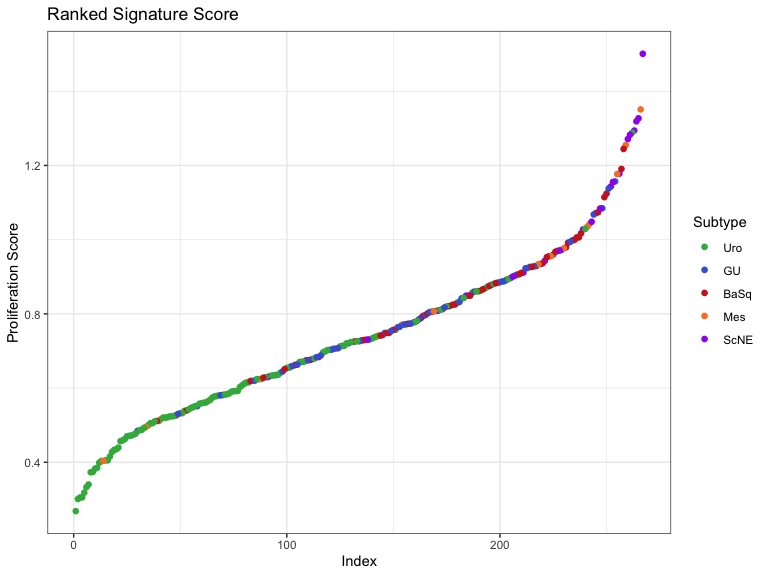

```r
plot_ranked_score(
  these_predictions = results,
  this_score = "proliferation_score",
  subtype_class = "5_class"
)
```

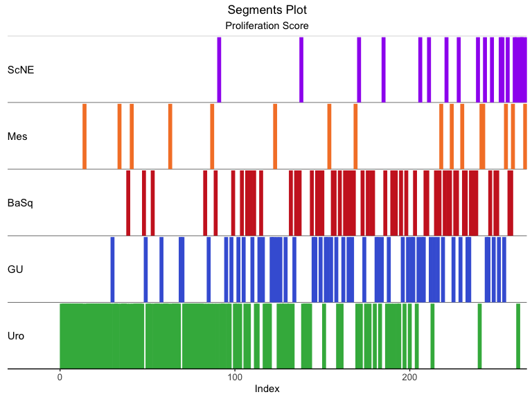

```r
plot_ranked_score(
  these_predictions = results,
  seg_width = 2,
  seg_plot = TRUE,
  this_score = "proliferation_score",
  subtype_class = "5_class"
)
```

**Example: Return Formatted Data**

```r
ranked_data <- plot_ranked_score(
  these_predictions = results,
  this_score = "proliferation_score",
  subtype_class = "5_class",
  return_data = TRUE
)
head(ranked_data)
```

```
#>   sample_id     score subtype rank
#> 1     1.CEL 0.7310869     Uro  139
#> 2     2.CEL 1.0419366     Mes  242
#> 3     3.CEL 0.4846604      GU   30
#> 4     4.CEL 0.6596973     Uro  103
#> 5     5.CEL 0.8079496     Uro  170
#> 6     6.CEL 0.9343730      GU  219
```

# 4 Subscore Visualizations

## 4.1 `plot_subscore_violin`

**Purpose:** Visualizes the distribution of subtype prediction scores for a selected subtype using violin plots. Useful for comparing score distributions across subtypes.

**Key Parameters:** - `these_predictions`: Output from `classify_samples` - `this_subtype`: Subtype to plot (e.g., “GU”, “UroA”) - `plot_adjust`: Bandwidth adjustment for violin smoothing - `plot_scale`: Area, count, or width scaling for violins - `plot_trim`: Whether to trim violin tails - `out_path`, `out_format`, `plot_width`, `plot_height`: Output controls - `return_data`: Set to TRUE to return tidy data

**Expected Inputs:** - Output from `classify_samples`

**Output:** - A ggplot violin plot, or a tidy data frame if `return_data = TRUE`

**Example: GU Subtype, Adjust Bandwidth, No Trim**

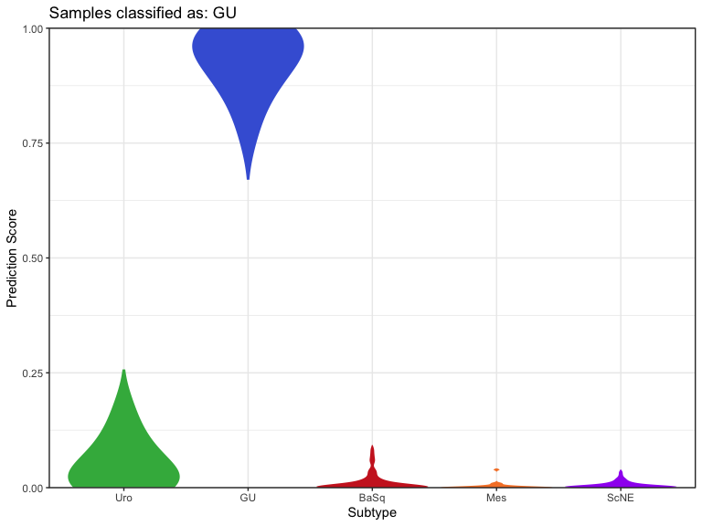

```r
plot_subscore_violin(
  these_predictions = results,
  this_subtype = "GU",
  plot_adjust = 2,
  plot_trim = FALSE
)
```

**Example: UroA Subtype, Area Scaling**

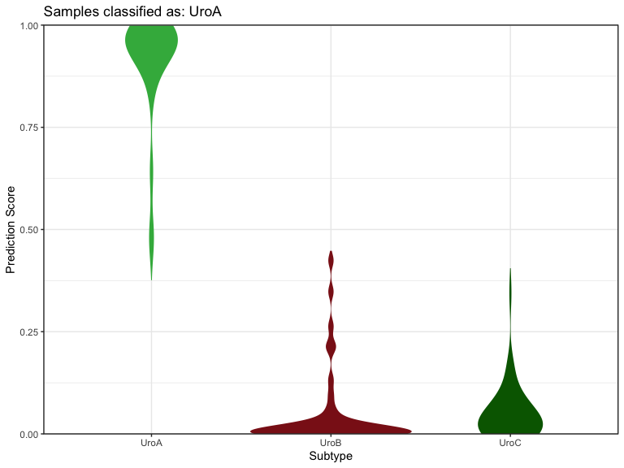

```r
plot_subscore_violin(
  these_predictions = results,
  this_subtype = "UroA",
  plot_scale = "area"
)
```

**Example: Return Tidy Data**

```r
violin_data <- plot_subscore_violin(
  these_predictions = results,
  this_subtype = "GU",
  return_data = TRUE
)
head(violin_data)
```

```
#>   sample_id subtype      value
#> 1     3.CEL     Uro 0.06820000
#> 2     6.CEL     Uro 0.00820000
#> 3     9.CEL     Uro 0.19140000
#> 4    11.CEL     Uro 0.10140000
#> 5    14.CEL     Uro 0.03906667
#> 6    16.CEL     Uro 0.00840000
```

## 4.2 `plot_subscore_box`

**Purpose:** Creates a stacked barplot of subtype prediction scores for a selected subtype, showing the distribution and ranking of scores.

**Key Parameters:** - `these_predictions`: Output from `classify_samples` - `this_subtype`: Subtype to plot (e.g., “Uro”, “UroA”) - `out_path`, `out_format`, `plot_width`, `plot_height`: Output controls - `return_data`: Set to TRUE to return tidy data

**Expected Inputs:** - Output from `classify_samples`

**Output:** - A ggplot stacked barplot, or a tidy data frame if `return_data = TRUE`

**Example: Uro Scores**

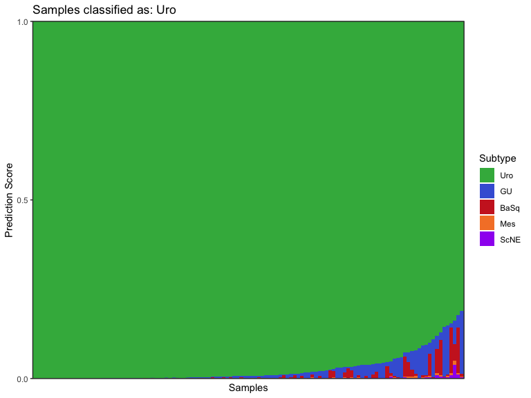

```r
plot_subscore_box(
  these_predictions = results,
  this_subtype = "Uro"
)
```

**Example: Return Tidy Data**

```r
box_data <- plot_subscore_box(
  these_predictions = results,
  this_subtype = "Uro",
  return_data = TRUE
)
head(box_data)
```

```
#> # A tibble: 6 × 3
#>   sample_id subtype value
#>   <fct>     <fct>   <dbl>
#> 1 15.CEL    Uro         1
#> 2 15.CEL    GU          0
#> 3 15.CEL    BaSq        0
#> 4 15.CEL    Mes         0
#> 5 15.CEL    ScNE        0
#> 6 45.CEL    Uro         1
```

Each visualization function in LundTaxR is designed for flexibility and publication-quality output. Adjust parameters and inputs as needed for your research, and use the `return_data` option to further customize or combine plots as needed.